# TidyTuesday

Collection of my data vizzes for #TidyTuesday!

### #8 18/02/2024

I keep saying I’ll do some more plots.. maybe this time  
R Consortium ISC Grant funding (View Code)

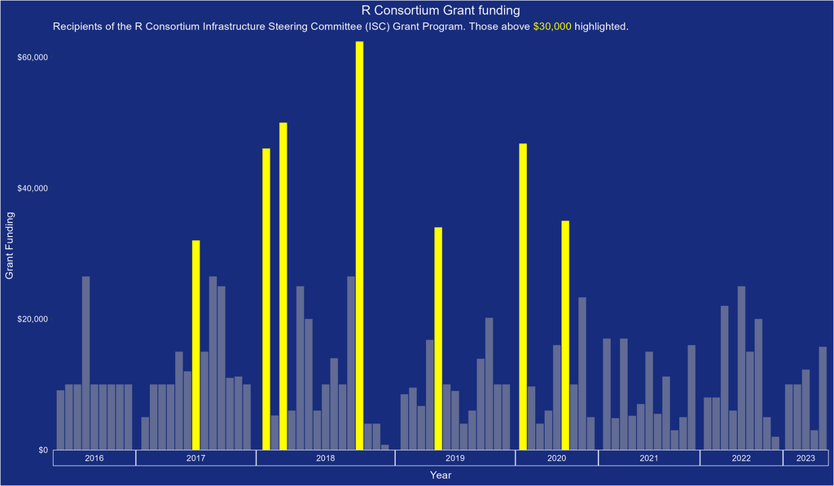

### #7 29/03/2022

Time to go back through the TidyTuesdays I’ve missed out on  
US College Sport Expenditure per Participant (View Code)

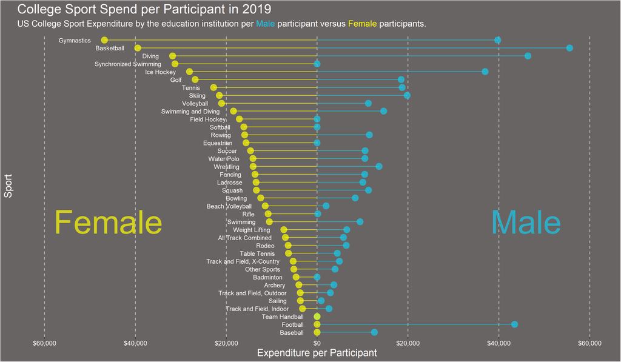

### #6 05/04/2022

Haven’t done a TidyTuesday plot in about a year …. oops  
North American News Corporation Revenue Streams (View Code)

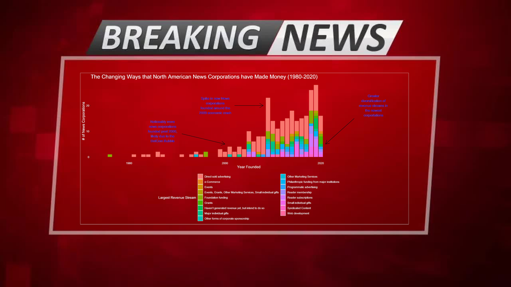

### #5 06/04/2021

Decided to get a bit more creative and make this one into a gif, took far too long to try and work out how to mock up a stacked bar inside of a country outline!  
Largest causes of deforestation in the Brazilian Amazon 2001 - 2013 (View Code)

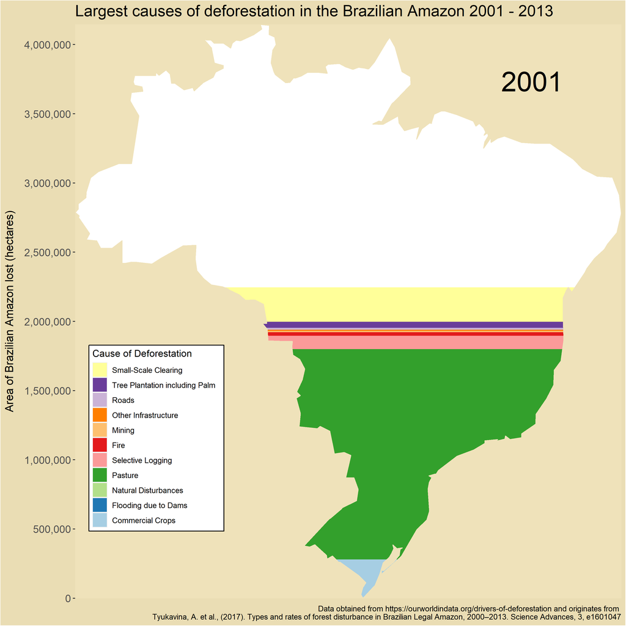

### #4 23/03/2021

Haven’t done a chloropleth yet in R so thought it was probably about time  
UN members and the world issues that they vote ‘no’ to most (View Code)

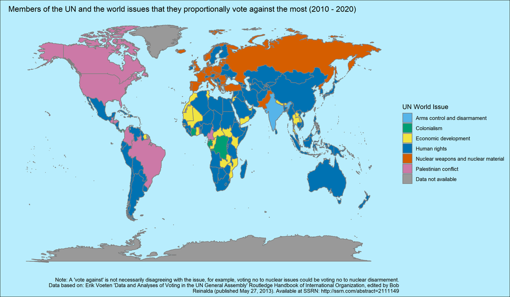

### #3 16/03/2021

Steam game popularity over time (View Code)

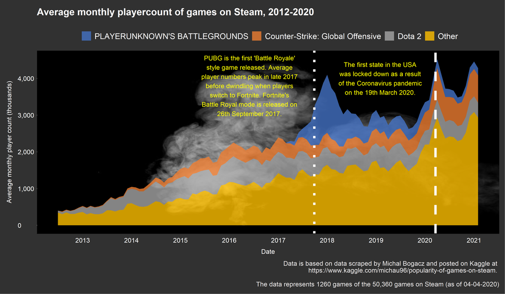

Fancied having a play around with cowplot to try and see how to organise plots neatly for future infographics  
Wealth and Income by Race and Generation (View Code)

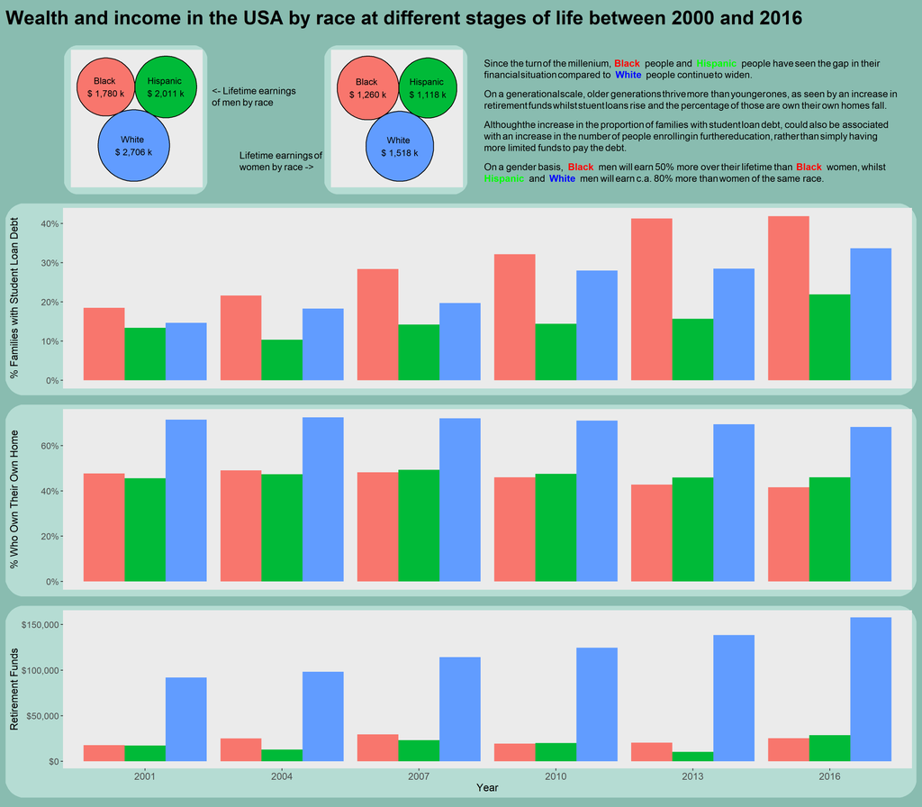

### #1 02/03/2021

Thought it might be a good idea to start trying to improve my data visualisation skills  
Superbowl adverts (View Code)

[figure not shown]